# Exploring the Correlation Between BMI and Sleep Apnea Using Supervised Learning

### Insights from Sleep Health and Lifestyle Dataset in Kaggle

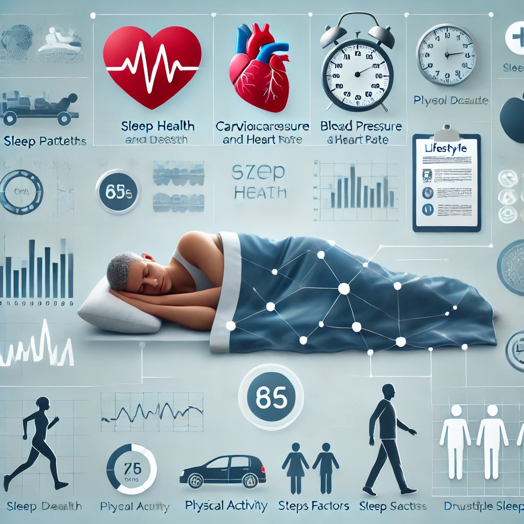

```python
from IPython.display import Image
Image(filename='Sleep Health and Lifestyle Study Visuals.png')
```

Citation: "Sleep Health and Lifestyle Study Visual." Created by OpenAI DALL-E, September 21, 2024.

Creative Commons CC0: Public Domain.

## Problem Statement:

The objective of this project is to predict the likelihood of Sleep Apnea in individuals based on their BMI Category and other relevant features using the Sleep Health and Lifestyle Dataset. Specifically, we aim to explore how different BMI categories (e.g., Underweight, Normal, Overweight, Obese) impact the occurrence of Sleep Apnea, a common sleep disorder.

### Key questions to be addressed:

- Is there a significant correlation between BMI Category and the likelihood of developing Sleep Apnea?
- How can machine learning models, based on BMI and other features (e.g., age, gender, physical activity), predict the risk of Sleep Apnea?
- Can we build an effective model to identify individuals at risk for Sleep Apnea based on their BMI Category?

The goal is to provide a data-driven model that can assist in identifying individuals at risk for sleep apnea, potentially helping in early diagnosis and intervention.

## Dataset Overview

### Key Features of the Dataset:

- **Comprehensive Sleep Metrics**: Sleep duration, quality, and factors influencing sleep patterns.
- **Lifestyle Factors**: Physical activity levels, stress, and BMI categories.
- **Cardiovascular Health**: Blood pressure and heart rate measurements.
- **Sleep Disorder Analysis**: Identification of sleep disorders such as Insomnia and Sleep Apnea.

### Dataset Columns:

- **Person ID**: Unique identifier for each individual.
- **Gender**: Male/Female.
- **Age**: Age in years.
- **Occupation**: Profession of the person.
- **Sleep Duration (hours)**: Hours of sleep per day.
- **Quality of Sleep (scale: 1-10)**: Rating of sleep quality.
- **Physical Activity Level (minutes/day)**: Minutes of physical activity daily.
- **Stress Level (scale: 1-10)**: Stress level rating.
- **BMI Category**: BMI classification (Underweight, Normal, Overweight, Obese).
- **Blood Pressure (systolic/diastolic)**: Blood pressure measurement.
- **Heart Rate (bpm)**: Resting heart rate in beats per minute.
- **Daily Steps**: Steps taken daily.
- **Sleep Disorder**: Classification (None, Insomnia, Sleep Apnea).

### Sleep Disorder Column Details:

- **None**: No sleep disorder.
- **Insomnia**: Difficulty falling or staying asleep.
- **Sleep Apnea**: Pauses in breathing during sleep.

## Data Preprocessing:

```python
# Import necessary libraries
import pandas as pd
import matplotlib.pyplot as plt
import seaborn as sns
import numpy as np
import pandas as pd
from sklearn.model_selection import train_test_split, cross_val_score, StratifiedKFold
from sklearn.preprocessing import LabelEncoder, StandardScaler
from sklearn.ensemble import RandomForestClassifier
from sklearn.linear_model import LogisticRegression
from imblearn.over_sampling import SMOTE
from sklearn.svm import SVC
from sklearn.metrics import accuracy_score, classification_report
from matplotlib import pyplot as plt
from sklearn.metrics import confusion_matrix

# Load the dataset
file_path = 'path_to_your_dataset.csv'  # Replace with the actual path to your dataset
data = pd.read_csv('Sleep_health_and_lifestyle_dataset.csv')

# Display the first few rows of the dataset
data.head()
```

|  | Person ID | Gender | Age | Occupation | Sleep Duration | Quality of Sleep | Physical Activity Level | Stress Level | BMI Category | Blood Pressure | Heart Rate | Daily Steps | Sleep Disorder |
| --- | --- | --- | --- | --- | --- | --- | --- | --- | --- | --- | --- | --- | --- |
| 0 | 1 | Male | 27 | Software Engineer | 6.1 | 6 | 42 | 6 | Overweight | 126/83 | 77 | 4200 | NaN |
| 1 | 2 | Male | 28 | Doctor | 6.2 | 6 | 60 | 8 | Normal | 125/80 | 75 | 10000 | NaN |
| 2 | 3 | Male | 28 | Doctor | 6.2 | 6 | 60 | 8 | Normal | 125/80 | 75 | 10000 | NaN |
| 3 | 4 | Male | 28 | Sales Representative | 5.9 | 4 | 30 | 8 | Obese | 140/90 | 85 | 3000 | Sleep Apnea |
| 4 | 5 | Male | 28 | Sales Representative | 5.9 | 4 | 30 | 8 | Obese | 140/90 | 85 | 3000 | Sleep Apnea |

```python
# Checking for missing values in the dataset
missing_values = data.isnull().sum()

# Display the missing values for each column
missing_values
```

```
Person ID                    0
Gender                       0
Age                          0
Occupation                   0
Sleep Duration               0
Quality of Sleep             0
Physical Activity Level      0
Stress Level                 0
BMI Category                 0
Blood Pressure               0
Heart Rate                   0
Daily Steps                  0
Sleep Disorder             219
dtype: int64
```

### Transforming Sleep Disorder to Binary

```python
# Filter out rows with 'Insomnia' in the Sleep Disorder column
data = data[data['Sleep Disorder'] != 'Insomnia']

# Convert 'Sleep Apnea' to 1 and NaN to 0 in the Sleep Disorder column
data['Sleep Disorder'] = data['Sleep Disorder'].map({'Sleep Apnea': 1}).fillna(0)

# Display the first few rows of the updated DataFrame to verify the changes
print("Updated DataFrame:")
data.head()
```

```
Updated DataFrame:
```

|  | Person ID | Gender | Age | Occupation | Sleep Duration | Quality of Sleep | Physical Activity Level | Stress Level | BMI Category | Blood Pressure | Heart Rate | Daily Steps | Sleep Disorder |
| --- | --- | --- | --- | --- | --- | --- | --- | --- | --- | --- | --- | --- | --- |
| 0 | 1 | Male | 27 | Software Engineer | 6.1 | 6 | 42 | 6 | Overweight | 126/83 | 77 | 4200 | 0.0 |
| 1 | 2 | Male | 28 | Doctor | 6.2 | 6 | 60 | 8 | Normal | 125/80 | 75 | 10000 | 0.0 |
| 2 | 3 | Male | 28 | Doctor | 6.2 | 6 | 60 | 8 | Normal | 125/80 | 75 | 10000 | 0.0 |
| 3 | 4 | Male | 28 | Sales Representative | 5.9 | 4 | 30 | 8 | Obese | 140/90 | 85 | 3000 | 1.0 |
| 4 | 5 | Male | 28 | Sales Representative | 5.9 | 4 | 30 | 8 | Obese | 140/90 | 85 | 3000 | 1.0 |

In this preprocessing step, we focused on the Sleep Disorder column of the dataset. First, we filtered out all rows where the Sleep Disorder was labeled as 'Insomnia', as we are only interested in analyzing 'Sleep Apnea' and 'None'. After removing these rows, we converted the remaining values in the Sleep Disorder column to numerical representations: 'Sleep Apnea' was mapped to 1, and any NaN values (which represent 'None' after the filtering) were filled with 0. This transformation allows us to use the Sleep Disorder column as a binary target variable in our machine learning models, facilitating the prediction of the likelihood of Sleep Apnea based on other features in the dataset.

### Transforming BMI Category to Binary

In this preprocessing step, I cleaned the dataset by addressing a duplicate category in the BMI Category column. Specifically, I replaced 'Normal Weight' with 'Normal' to consolidate these categories. Additionally, I deleted rows where the BMI Category was 'Obese', treating these as outliers. After cleaning the data, I transformed the BMI Category column to create a binary classification: 'Overweight' was mapped to 1, and all other categories were mapped to 0. This transformation simplifies the BMI Category column into a binary feature, making it easier to use in machine learning models for predicting the likelihood of Sleep Apnea based on BMI and other relevant features. After applying the transformation, I printed the first few rows of the updated DataFrame to verify the changes.

```python
# Replace 'Normal Weight' with 'Normal' in the BMI Category column
data['BMI Category'] = data['BMI Category'].replace('Normal Weight', 'Normal')

# Delete rows with 'Obese' in the BMI Category column
data = data[data['BMI Category'] != 'Obese']

# Display the first few rows of the updated DataFrame to verify the changes
print("Updated DataFrame:")
data
```

```
Updated DataFrame:
```

|  | Person ID | Gender | Age | Occupation | Sleep Duration | Quality of Sleep | Physical Activity Level | Stress Level | BMI Category | Blood Pressure | Heart Rate | Daily Steps | Sleep Disorder |
| --- | --- | --- | --- | --- | --- | --- | --- | --- | --- | --- | --- | --- | --- |
| 0 | 1 | Male | 27 | Software Engineer | 6.1 | 6 | 42 | 6 | Overweight | 126/83 | 77 | 4200 | 0.0 |
| 1 | 2 | Male | 28 | Doctor | 6.2 | 6 | 60 | 8 | Normal | 125/80 | 75 | 10000 | 0.0 |
| 2 | 3 | Male | 28 | Doctor | 6.2 | 6 | 60 | 8 | Normal | 125/80 | 75 | 10000 | 0.0 |
| 7 | 8 | Male | 29 | Doctor | 7.8 | 7 | 75 | 6 | Normal | 120/80 | 70 | 8000 | 0.0 |
| 8 | 9 | Male | 29 | Doctor | 7.8 | 7 | 75 | 6 | Normal | 120/80 | 70 | 8000 | 0.0 |
| ... | ... | ... | ... | ... | ... | ... | ... | ... | ... | ... | ... | ... | ... |
| 369 | 370 | Female | 59 | Nurse | 8.1 | 9 | 75 | 3 | Overweight | 140/95 | 68 | 7000 | 1.0 |
| 370 | 371 | Female | 59 | Nurse | 8.0 | 9 | 75 | 3 | Overweight | 140/95 | 68 | 7000 | 1.0 |
| 371 | 372 | Female | 59 | Nurse | 8.1 | 9 | 75 | 3 | Overweight | 140/95 | 68 | 7000 | 1.0 |
| 372 | 373 | Female | 59 | Nurse | 8.1 | 9 | 75 | 3 | Overweight | 140/95 | 68 | 7000 | 1.0 |
| 373 | 374 | Female | 59 | Nurse | 8.1 | 9 | 75 | 3 | Overweight | 140/95 | 68 | 7000 | 1.0 |

291 rows × 13 columns

```python
# Convert 'Overweight' to 1 and all others to 0 in the BMI Category column
data['BMI Category'] = data['BMI Category'].map({'Overweight': 1}).fillna(0)

# Display the first few rows of the updated DataFrame to verify the changes
print("Updated DataFrame:")
data
```

```
Updated DataFrame:
```

|  | Person ID | Gender | Age | Occupation | Sleep Duration | Quality of Sleep | Physical Activity Level | Stress Level | BMI Category | Blood Pressure | Heart Rate | Daily Steps | Sleep Disorder |
| --- | --- | --- | --- | --- | --- | --- | --- | --- | --- | --- | --- | --- | --- |
| 0 | 1 | Male | 27 | Software Engineer | 6.1 | 6 | 42 | 6 | 1.0 | 126/83 | 77 | 4200 | 0.0 |
| 1 | 2 | Male | 28 | Doctor | 6.2 | 6 | 60 | 8 | 0.0 | 125/80 | 75 | 10000 | 0.0 |
| 2 | 3 | Male | 28 | Doctor | 6.2 | 6 | 60 | 8 | 0.0 | 125/80 | 75 | 10000 | 0.0 |
| 7 | 8 | Male | 29 | Doctor | 7.8 | 7 | 75 | 6 | 0.0 | 120/80 | 70 | 8000 | 0.0 |
| 8 | 9 | Male | 29 | Doctor | 7.8 | 7 | 75 | 6 | 0.0 | 120/80 | 70 | 8000 | 0.0 |
| ... | ... | ... | ... | ... | ... | ... | ... | ... | ... | ... | ... | ... | ... |
| 369 | 370 | Female | 59 | Nurse | 8.1 | 9 | 75 | 3 | 1.0 | 140/95 | 68 | 7000 | 1.0 |
| 370 | 371 | Female | 59 | Nurse | 8.0 | 9 | 75 | 3 | 1.0 | 140/95 | 68 | 7000 | 1.0 |
| 371 | 372 | Female | 59 | Nurse | 8.1 | 9 | 75 | 3 | 1.0 | 140/95 | 68 | 7000 | 1.0 |
| 372 | 373 | Female | 59 | Nurse | 8.1 | 9 | 75 | 3 | 1.0 | 140/95 | 68 | 7000 | 1.0 |
| 373 | 374 | Female | 59 | Nurse | 8.1 | 9 | 75 | 3 | 1.0 | 140/95 | 68 | 7000 | 1.0 |

291 rows × 13 columns

### Spliting the Data into Training and Testing Sets:

The dataset was split into training and testing sets using the `train_test_split` function:

- **75%** of the data was used for training, and **25%** was reserved for testing.
- This ensures that the model can learn from one portion of the data and then be evaluated on unseen data to test its generalization ability.

```python
# Split the dataset into training and testing sets (75% training, 25% testing)
X_train, X_test, y_train, y_test = train_test_split(X, y, test_size=0.25, random_state=42)
```

## Model Training:

### Supervised Machine Learning Models for this Project

For this project, I will be using the following three supervised machine learning models:

#### 1. Random Forest Classifier

- **Why**:  
  Random Forest is an ensemble learning method that builds multiple decision trees and averages their predictions. It is highly effective at handling both categorical and numerical features, is robust to overfitting, and can provide feature importance, which helps in understanding the significance of variables like BMI Category in relation to sleep apnea.
- **Pros**:
  - High accuracy
  - Can handle complex interactions between variables
  - Reduces the risk of overfitting
- **Cons**:
  - Less interpretable compared to simpler models like Logistic Regression

#### 2. Logistic Regression

- **Why**:  
  Logistic Regression is a simple, interpretable, and efficient model for binary classification tasks such as predicting sleep apnea. It offers probabilistic outcomes for class membership and aids in understanding the relationship between variables, such as BMI Category and the likelihood of sleep apnea.
- **Pros**:
  - Easy to implement
  - Highly interpretable
  - Works well for linearly separable data
- **Cons**:
  - May struggle with capturing complex relationships between features

#### 3. Support Vector Machine (SVM)

- **Why**:  
  SVM is a powerful model for classification tasks, particularly in high-dimensional datasets. It aims to find the optimal boundary that separates different classes (e.g., sleep apnea vs. no sleep apnea). SVM can handle both linear and non-linear classification problems using different kernel functions.
- **Pros**:
  - Effective for small to medium-sized datasets
  - Can handle complex decision boundaries
- **Cons**:
  - Computationally expensive for large datasets
  - Requires careful tuning of parameters such as the kernel and regularization

### Supervised Machine Learning Implementation

#### Random Forest Classifier

```python
# Define the features (X) and target (y) for the model
X = data[['BMI Category']]
y = data['Sleep Disorder']  # Sleep Disorder is the target variable

# Initialize the Random Forest Classifier
rf_classifier = RandomForestClassifier(n_estimators=100, random_state=42)

# Train the model
rf_classifier.fit(X_train, y_train)

# Make predictions on the testing set
y_pred = rf_classifier.predict(X_test)

# Evaluate the model
accuracy = accuracy_score(y_test, y_pred)
report = classification_report(y_test, y_pred)

# Display the results
print(f"Accuracy: {accuracy}")
print("Classification Report:")
print(report)
```

```
Accuracy: 0.9452054794520548
Classification Report:
              precision    recall  f1-score   support

         0.0       0.98      0.95      0.96        56
         1.0       0.84      0.94      0.89        17

    accuracy                           0.95        73
   macro avg       0.91      0.94      0.93        73
weighted avg       0.95      0.95      0.95        73
```

#### Logistic Regression

```python
# Apply SMOTE to the training data
smote = SMOTE(random_state=42)
X_train_balanced, y_train_balanced = smote.fit_resample(X_train, y_train)

# Check the distribution of classes in the balanced training set
print("Class distribution in the balanced training set:")
print(y_train_balanced.value_counts())

# Initialize and train the Logistic Regression model
log_reg = LogisticRegression(random_state=42)
log_reg.fit(X_train_balanced, y_train_balanced)

# Make predictions on the testing set
y_pred = log_reg.predict(X_test)

# Evaluate the model
accuracy = accuracy_score(y_test, y_pred)
report = classification_report(y_test, y_pred)

print(f"Accuracy: {accuracy}")
print("Classification Report:")
print(report)
```

```
Class distribution in the balanced training set:
Sleep Disorder
0.0    163
1.0    163
Name: count, dtype: int64
Accuracy: 0.9452054794520548
Classification Report:
              precision    recall  f1-score   support

         0.0       0.98      0.95      0.96        56
         1.0       0.84      0.94      0.89        17

    accuracy                           0.95        73
   macro avg       0.91      0.94      0.93        73
weighted avg       0.95      0.95      0.95        73
```

#### Support Vector Machine (SVM)

```python
# Initialize and train the SVM model
svm_model = SVC(random_state=42)
svm_model.fit(X_train_balanced, y_train_balanced)

# Make predictions on the testing set
y_pred = svm_model.predict(X_test)

# Evaluate the model
accuracy = accuracy_score(y_test, y_pred)
report = classification_report(y_test, y_pred)

print(f"Accuracy: {accuracy}")
print("Classification Report:")
print(report)

# Cross-validation
cv = StratifiedKFold(n_splits=5, shuffle=True, random_state=42)
cv_scores = cross_val_score(svm_model, X, y, cv=cv, scoring='accuracy')

print(f"Cross-Validation Accuracy Scores: {cv_scores}")
print(f"Mean Cross-Validation Accuracy: {cv_scores.mean()}")
print(f"Standard Deviation of Cross-Validation Accuracy: {cv_scores.std()}")
```

```
Accuracy: 0.9452054794520548
Classification Report:
              precision    recall  f1-score   support

         0.0       0.98      0.95      0.96        56
         1.0       0.84      0.94      0.89        17

    accuracy                           0.95        73
   macro avg       0.91      0.94      0.93        73
weighted avg       0.95      0.95      0.95        73

Cross-Validation Accuracy Scores: [0.96610169 0.9137931  0.9137931  0.86206897 0.89655172]
Mean Cross-Validation Accuracy: 0.9104617182933957
Standard Deviation of Cross-Validation Accuracy: 0.033625435941383224
```

### Comparative Analysis of Three Models

In this project, you used three models: Random Forest Classifier, Logistic Regression, and Support Vector Machine (SVM). Below is a comparative analysis of these models based on their performance metrics.

#### Performance Metrics

1. **Random Forest Classifier:**
   - **Accuracy:** 0.9452
   - **Precision:**
     - Class 0: 0.98
     - Class 1: 0.84
   - **Recall:**
     - Class 0: 0.95
     - Class 1: 0.94
   - **F1 Score:**
     - Class 0: 0.96
     - Class 1: 0.89
   - **Classification Report:**

     ```
                  precision    recall  f1-score   support

             0.0       0.98      0.95      0.96        56
             1.0       0.84      0.94      0.89        17

        accuracy                           0.95        73
       macro avg       0.91      0.94      0.93        73
     ```

     ```
                  precision    recall  f1-score   support

             0.0       0.98      0.95      0.96        56
             1.0       0.84      0.94      0.89        17

        accuracy                           0.95        73
       macro avg       0.91      0.94      0.93        73
     ```

     ```
                  precision    recall  f1-score   support

             0.0       0.98      0.95      0.96        56
             1.0       0.84      0.94      0.89        17

        accuracy                           0.95        73
       macro avg       0.91      0.94      0.93        73
     ```

### Strengths and Weaknesses

1. **Random Forest Classifier:**
   - **Strengths:**
     - **Robust to Overfitting:** Less prone to overfitting due to the ensemble approach.
     - **Handles Missing Values:** Can handle missing values and maintain accuracy even when a large proportion of the data is missing.
     - **Feature Importance:** Provides insights into feature importance.
   - **Weaknesses:**
     - **Computationally Intensive:** Training and predicting can be computationally intensive.
     - **Less Interpretability:** The overall model is less interpretable compared to simpler models like decision trees.
2. **Logistic Regression:**
   - **Strengths:**
     - **Simplicity and Interpretability:** Simple to implement and interpret.
     - **Efficiency:** Computationally efficient and works well with large datasets.
     - **Probabilistic Output:** Provides probabilistic outputs.
   - **Weaknesses:**
     - **Linear Decision Boundary:** Assumes a linear relationship between the features and the target.
     - **Sensitivity to Outliers:** Can be sensitive to outliers.
3. **Support Vector Machine (SVM):**
   - **Strengths:**
     - **Effective in High-Dimensional Spaces:** Suitable for problems where the number of features is greater than the number of samples.
     - **Robust to Overfitting:** Less prone to overfitting due to the regularization parameter.
     - **Clear Margin of Separation:** Aims to find the hyperplane that best separates the classes with the maximum margin.
   - **Weaknesses:**
     - **Computationally Intensive:** Training can be computationally intensive.
     - **Less Effective with Noisy Data:** Can be less effective when the data is noisy and overlapping.
     - **Parameter Tuning:** Requires careful tuning of parameters.

All three models—Random Forest Classifier, Logistic Regression, and SVM—achieved the same accuracy of 0.9452 and similar precision, recall, and F1 scores. The choice between them depends on the specific context of the problem and the characteristics of the dataset. Logistic Regression is simple and interpretable but may not capture complex patterns. SVMs are effective in high-dimensional spaces and provide a clear margin of separation but can be computationally intensive and sensitive to noisy data. Random Forests are robust to overfitting, handle missing values well, and provide feature importance insights but can be computationally intensive and less interpretable.

In the context of predicting sleep disorders based on BMI category, all three models can be effective. The final choice should be based on the specific performance metrics, computational resources, and the need for interpretability. Cross-validation results provide a robust estimate of the model's performance, and the model with the higher mean cross-validation accuracy and better evaluation metrics should be preferred. In this case, SVM has a mean cross-validation accuracy of 0.9105, which is a strong indicator of its robustness.